# Landmark displacement measurements

Thomas Guillerme

2018-12-13

This vignette illustrates the differences in measuring landmark displacement (or variation).

## Requirements and data

### The packages

This test will be using the `landvR` package from github and will require `devtools`, `geomorph` and `dispRity` from the CRAN. All these packages can be loaded easily as follows

```r
## Loading the libraries (and installing if necessary)
if(!require(devtools)) install.packages("devtools")
if(!require(geomorph)) install.packages("geomorph")
if(!require(landvR)) install_github("TGuillerme/landvR")

## Setting a random seed for the repeatability of this tutorial
set.seed(42)
```

### The data

This whole method is based on Procrustes superimpositions that can be easily done through the `geomorph` package (see the `geomorph` manual and especially the function `gpagen` for more details). For this example, we will be using the `plethodon` dataset from the `geomorph` `R` package.

```r
## Loading the dataset
data(plethodon)

## Generating a Procrustes superimposition
procrustes <- gpagen(plethodon$land, print.progress = FALSE)
```

This results in a dataset of 40 Procrustes superimposition of 12 landmarks each.

# Landmark displacement

First lets get the two most different specimens for simplifying the comparisons:

```r
## Getting the two most different specimens
extreme_spec <- variation.range(procrustes, return.ID = TRUE)$min.max

## Separating the specimens
specimen_1 <- procrustes$coords[, , extreme_spec[1]]
specimen_2 <- procrustes$coords[, , extreme_spec[2]]
```

We can then measure the landmark displacements between a focal specimen (specimen 1, in blue below) and a reference one (specimen 2, in orange). Typically the focal one can be all the observed specimens and the reference one could be the mean or median landmark configuration.

These landmark displacements can be measured using two coordinates systems: the spherical or the vector one and is always measured between $F_{n}$ and $R_{n}$, respectively the $n^{th}$ landmark of the focal specimen and the reference. $F_{n}$ and $R_{n}$ are defined by two or three coordinates *x, y, z* depending on the number of dimensions in the system.

## Spherical coordinates

The spherical coordinates measure the landmark’s displacement in spherical coordinates systems for each landmark individually. In other words, the values for each landmark displacement is discrete in space (i.e. independent from other landmarks).

The [spherical coordinate system](https://en.wikipedia.org/wiki/Spherical_coordinate_system) is a 3D (or 2D) referential centred on a point of origin (here the $n^{th}$ landmark of the focal specimen). The system is defined by two or three variables (for respectively 2D and 3D systems):

- $\rho$, the Euclidean distance between $F_{n}$ and $R_{n}$.
- $\phi$, the azimuth angle formed by the projection of $R_{n}$ on the equatorial plan ($f_{(x)}=0$).
- $\theta$ (for 3D only), the polar angle formed by the projection $R_{n}$ on the polar plan ($f{(y)=0}$)

In `landvR` they are measured using basic algebra and trigonometry through the following function:

```r
## Measuring the spherical coordinates between specimen 1 (focal) and 2 (reference)
spherical_diff <- coordinates.difference(coordinates = specimen_1, reference = specimen_2,
                                        type = "spherical", angle = "degree")[[1]]
```

```r
## The differences between the two selected specimens
spherical_diff
```

```
##            radius   azimuth
##  [1,] 0.015154920 48.558836
##  [2,] 0.056550779 32.649301
##  [3,] 0.070087218 23.584891
##  [4,] 0.020754872 86.333453
##  [5,] 0.014831446 34.103072
##  [6,] 0.034482428 72.125643
##  [7,] 0.052406817 58.952595
##  [8,] 0.015595846 29.388294
##  [9,] 0.042363538 44.790597
## [10,] 0.009759552 15.401958
## [11,] 0.076345817  4.720584
## [12,] 0.042128720 55.072969
```

In this case, for each landmark, the longer the radii $\rho$, the more it is displaced and the bigger the azimuth $\phi$, the more away from the equatorial plan.

Here is a graphical representation of the system for a single landmark (3) with a radius of 0.0700872 and an angle of 23.5848906 degrees.

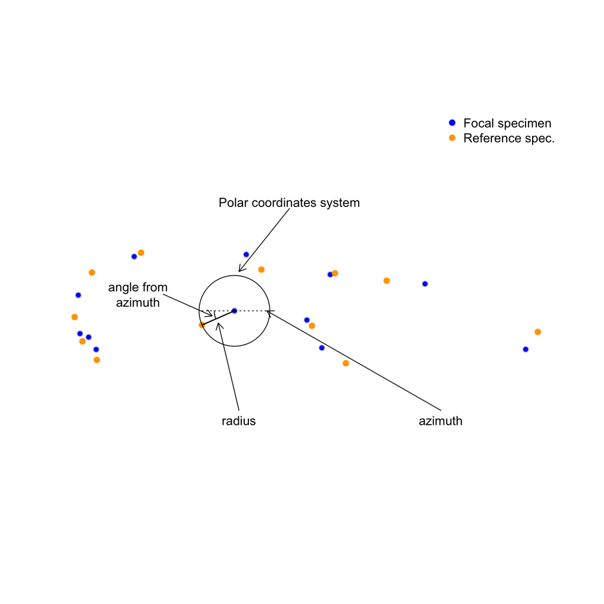

This system has the advantage of directly measuring the landmark displacement in *any* direction and to be independent from other landmarks within the same specimen. However, the azimuth and polar angle are often hard to interpret in isolation since they are relative to the equatorial and polar plan of the specimens (which can be arbitrary).

## Vector coordinates

The vector coordinates system is a bit different than the spherical one in that it is based on the landmark displacements relative to the centroid of the reference specimen. The centroid point of the reference, $C$, is the mean of all the *x, y, z* coordinates for all the landmarks of the reference specmin. This coordinate system is based on the vectors between the centroid $C$ and $F_{n}$ or $R_{n}$. These two vectors are called $\bf{v}_{Fn}$ and $\bf{v}_{Rn}$ respectively. The system is defined by two variables (regardless of the number of dimensions):

- the displacement length which is the difference between both vectors ($||\bf{v}_{Rn}|| - ||\bf{v}_{Fn}||$)
- the angle between the two vectors $\bf{v}_{Fn}$ and $\bf{v}_{Rn}$

In `landvR` they are measured using basic vector operations through the following function:

```r
## Measuring the spherical coordinates between specimen 1 (focal) and 2 (reference)
vector_diff <- coordinates.difference(coordinates = specimen_1, reference = specimen_2,
                                      type = "vector", angle = "degree",
                                      absolute.distance = FALSE)[[1]]
```

```r
## The differences between the two selected specimens
vector_diff
```

```
##             length     angle
##  [1,] -0.011983265  3.741149
##  [2,] -0.056155071  1.846975
##  [3,] -0.070039331  5.417873
##  [4,] -0.005007085  3.894607
##  [5,] -0.013642722  1.076431
##  [6,] -0.007305423  5.993309
##  [7,]  0.019240177  9.022292
##  [8,]  0.008311100  3.311774
##  [9,]  0.019129391 21.852162
## [10,] -0.009716796  0.263511
## [11,]  0.074060097  3.189630
## [12,] -0.020314545  3.623498
```

In this case, for each landmark, the longer the difference in length (in absolute value), the more it is displaced and the bigger the angle, the more it is offset. In terms of biology, if all lengths are positive and all angles are close to 0, the specimen is simply generally bigger (with no major changes in shape). On the other hand, if the lengths are close to 0 but the angles are high, the specimen is not bigger but still “deformed”,

Here is a graphical representation of the system for a single landmark (7) with a difference of 0.0192402 and an angle of 9.0222921 degrees:

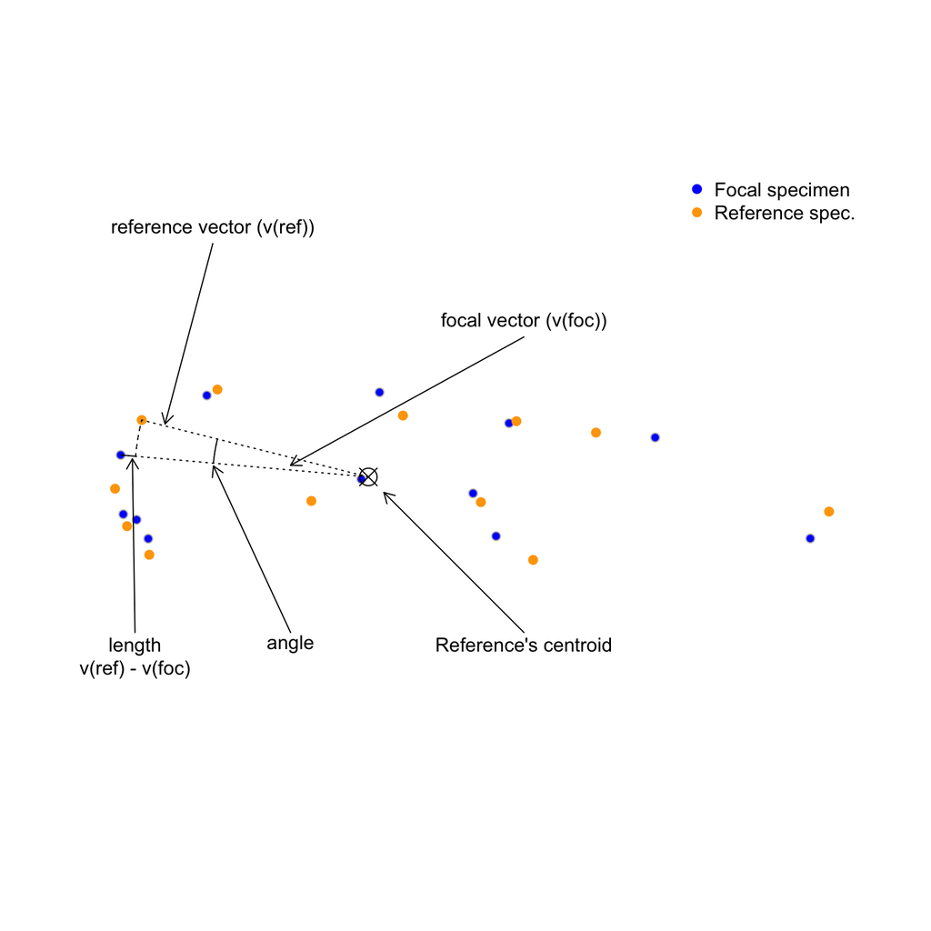

This coordinate system has the advantage to be more interpretable biologically (i.e. the length and angle will give a clear overview of how the landmark has moved relative to the reference) but the measurements are always relative to the reference and dependent on the other landmarks (used to calculate the centroid point).